# Data Visualisation

This document introduces Data Visualisation in R.

All code given in this introduction can be used/redone by you using your own locally installed R in RStudio. Following and testing all code is highly recommended to become familiar with code and functions.

# 01 Setup

Please set your working directory, and load the `SfL` package and the `data_s` data set:

```r
setwd("C:/.../.../.../.../R_Workshop")

library(SfL)

data("data_s")
```

Finally, we will re-level the typeOfS variable:

```r
data_s$typeOfS <- factor(data_s$typeOfS, levels = c("nm", "pl", "is"))
```

This order reflects the main idea of this data set: non-morphemic /s/ should be longest, is-clitic /s/ should be shortest.

# 02 ggplot2

Most data visualisation in R is done using the `ggplot2` package. `ggplot2` follows the ideas of *The Grammar of Graphics*, a seminal work on data visualisation by Leland Wilkinson.

In `ggplot2`, each plot consists of 3 elements:

## data

The `data` argument specifies where `ggplot` should look for variables you specify later on. Calling only the `data` element results in an empty plot:

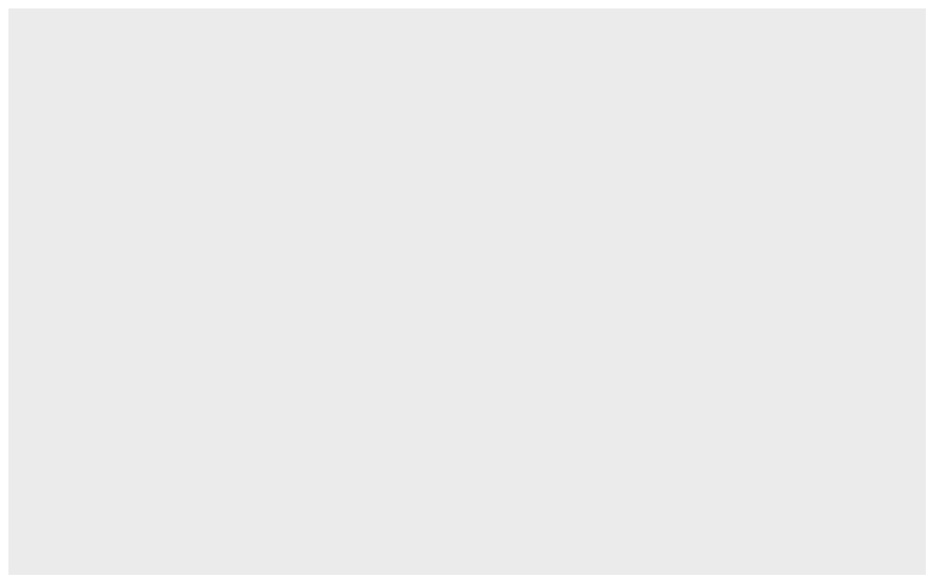

```r
ggplot(data_s)
```

## aesthetics

The `aes` element is used to specify variables for plotting. Depending on the type of plot, X, Y, a fill colour, and a line colour, among other things, can be specified.

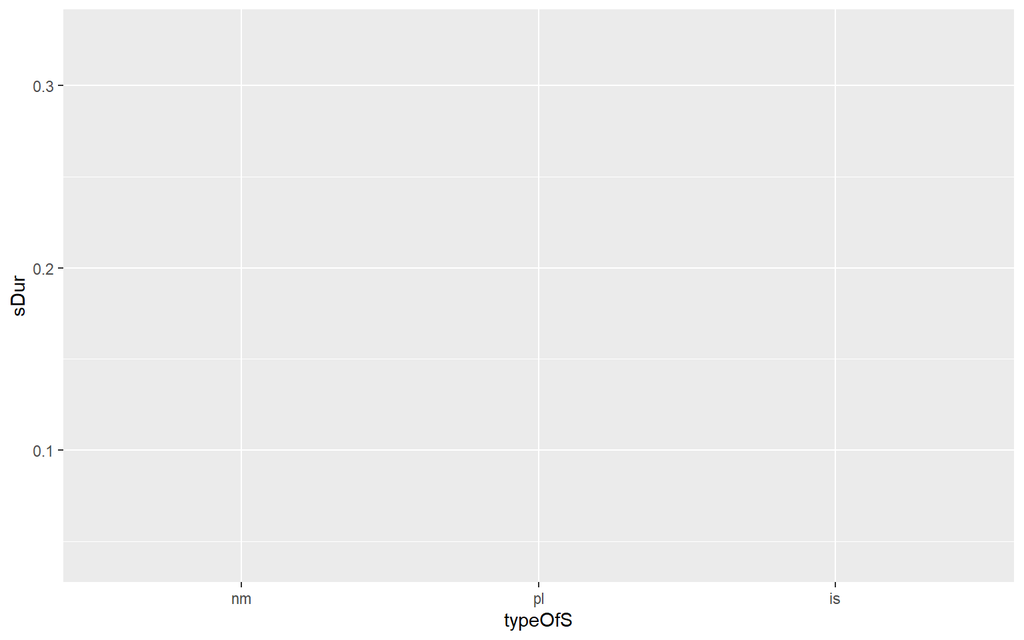

```r
ggplot(data_s, aes(x=typeOfS, y=sDur))
```

## geometric object

The `geom` is where the fun begins. The geom element is used to specify what type of plot you wish to create, e.g. a box plot. To keep code readable, use `+` and line breaks.

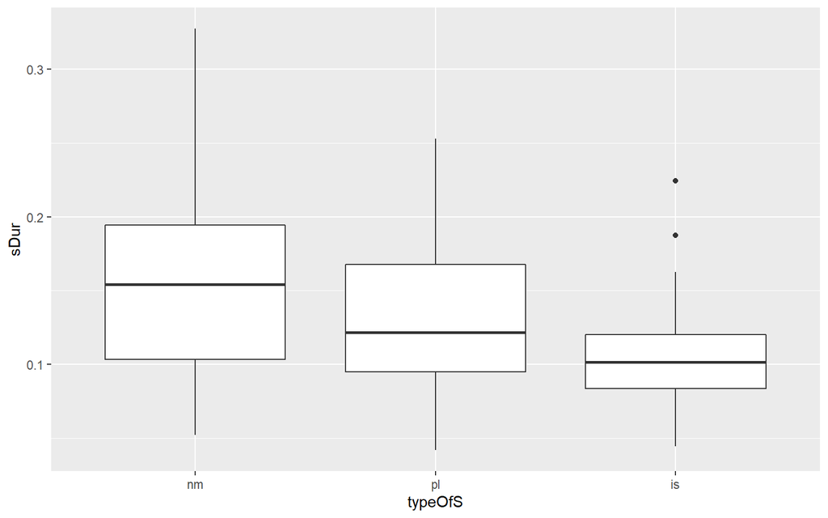

```r
ggplot(data_s, aes(x=typeOfS, y=sDur)) +
  geom_boxplot()
```

## first modifications

`ggplot2` includes many options to change and modify plots. We will take a quick look at some of them; more options are given later on. Note that modifications which include a variable name are given in the `aes` element, while modification which to not refer to a variable are given in the `geom` element.

### colours

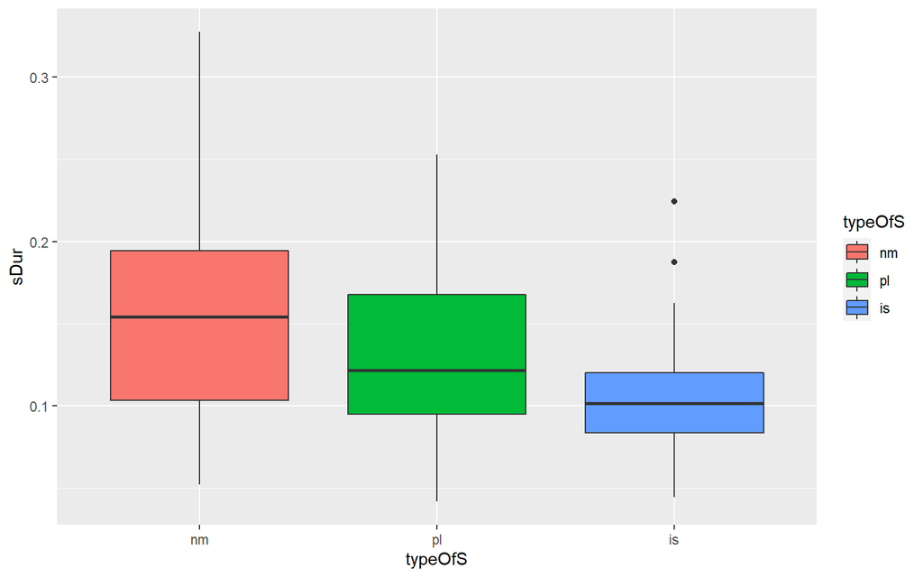

```r
ggplot(data_s, aes(x=typeOfS, y=sDur, fill=typeOfS)) +
  geom_boxplot()
```

### line weight

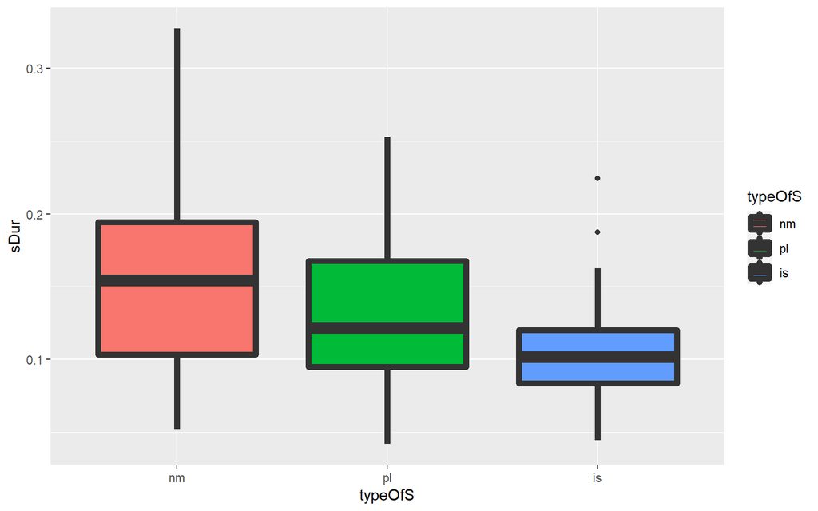

```r
ggplot(data_s, aes(x=typeOfS, y=sDur, fill=typeOfS)) +
  geom_boxplot(size=2)
```

### transparency

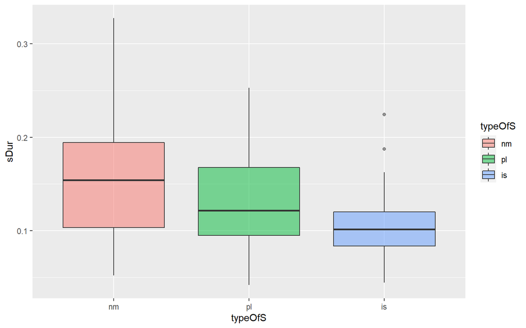

```r
ggplot(data_s, aes(x=typeOfS, y=sDur, fill=typeOfS)) +
  geom_boxplot(alpha=0.5)
```

# 03 Bar Plot

In most cases, bar plots display mean values. That is, each bar displays the mean value of a grouping factor’s level:

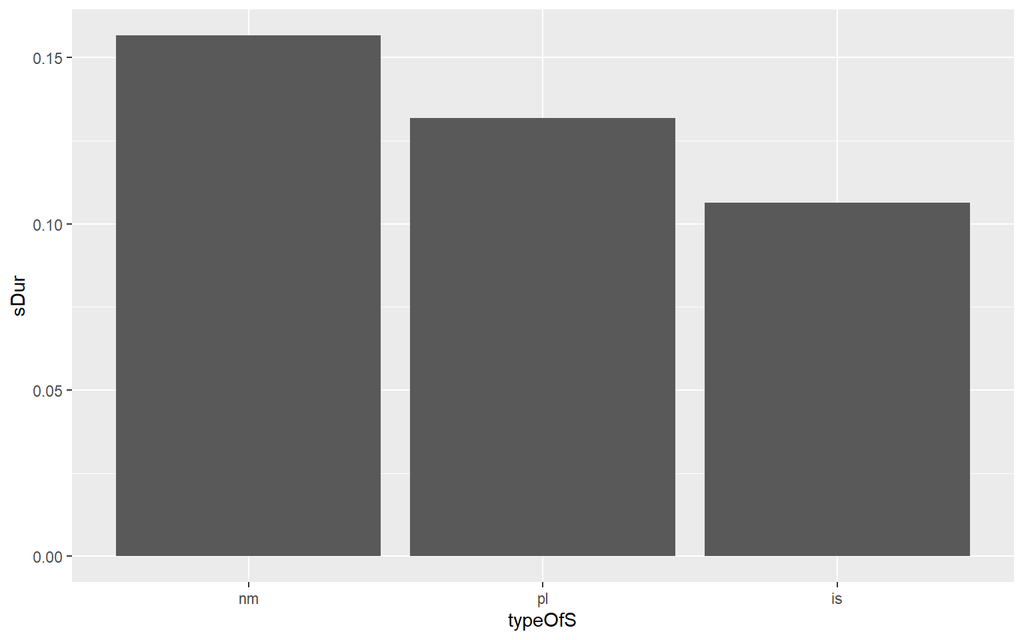

```r
ggplot(data_s, aes(x=typeOfS, y=sDur)) +
  geom_bar(stat="summary", fun = "mean")
```

We can check whether the height of the three bars actually displays the level’s mean values:

```r
mean(data_s$sDur[data_s$typeOfS=="nm"])
```

```
[1] 0.156608
```

```r
mean(data_s$sDur[data_s$typeOfS=="pl"])
```

```
[1] 0.1317052
```

```r
mean(data_s$sDur[data_s$typeOfS=="is"])
```

```
[1] 0.1062782
```

Indeed, the numbers match the bars.

We can easily add colours to the bar plot by adding a `fill` argument:

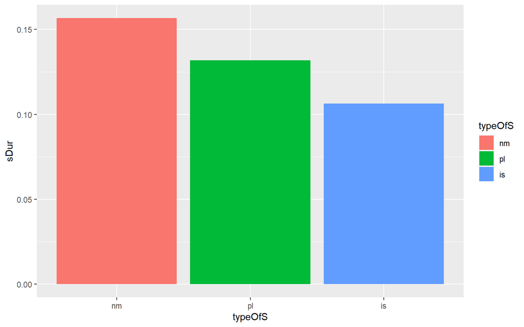

```r
ggplot(data_s, aes(x=typeOfS, y=sDur, fill=typeOfS)) +
  geom_bar(stat="summary", fun = "mean")
```

## Exercises

Create two bar plots using the `data_v` data set.

**Solution**

Two possible plots are:

```r
data("data_v")

ggplot(data_v, aes(x=vowel, y=duration)) +
  geom_bar(stat="summary", fun = "mean")

ggplot(data_v, aes(x=structure, y=duration, fill=structure)) +
  geom_bar(stat="summary", fun = "mean")
```

# 04 Box Plot

Even though a lot less intuitive to read than other plot types, box plots can often be found in linguistic papers, especially in phonetic research. They are easily created using `ggplot2`:

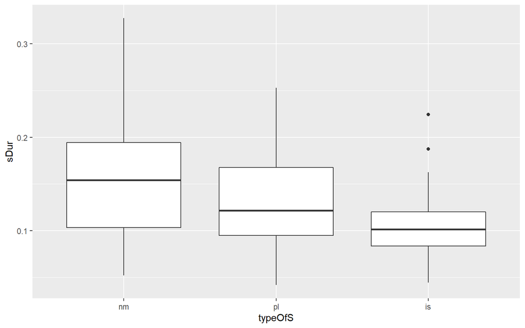

```r
ggplot(data_s, aes(x=typeOfS, y=sDur)) +
  geom_boxplot()
```

Box plots can be modified just like all other plots, e.g.:

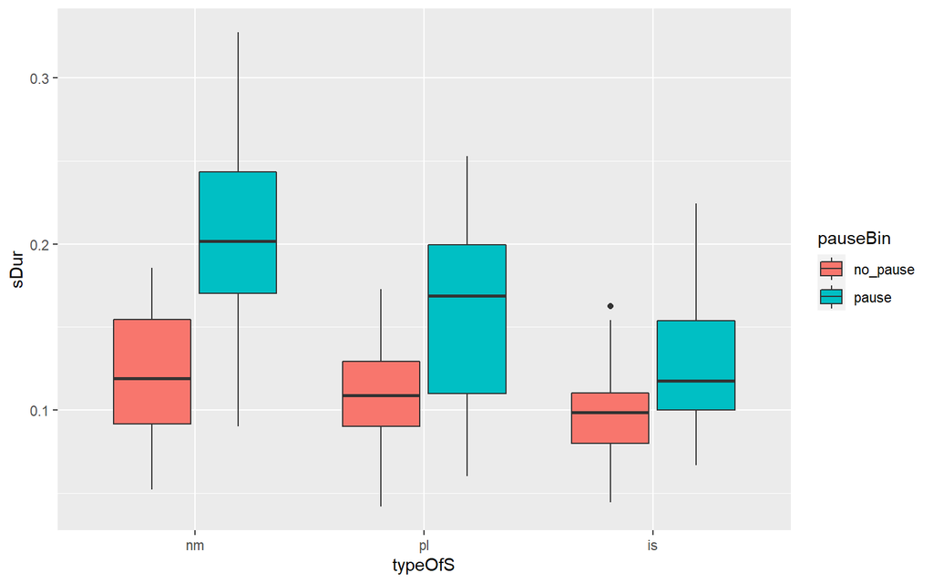

```r
ggplot(data_s, aes(x=typeOfS, y=sDur, fill=pauseBin)) +
  geom_boxplot()
```

## Exercises

Create two box plots using the `data_v` data set.

**Solution**

Two possible plots are:

```r
data("data_v")

ggplot(data_v, aes(x=structure, y=duration, fill=structure)) +
  geom_boxplot()

ggplot(data_v, aes(x=structure, y=duration, fill=vowel)) +
  geom_boxplot()
```

# 05 Point Plot

Point plots are rarely found in the wild - but they belong to the basic knowledge of data visualisation. We can create point plots using `ggplot2`:

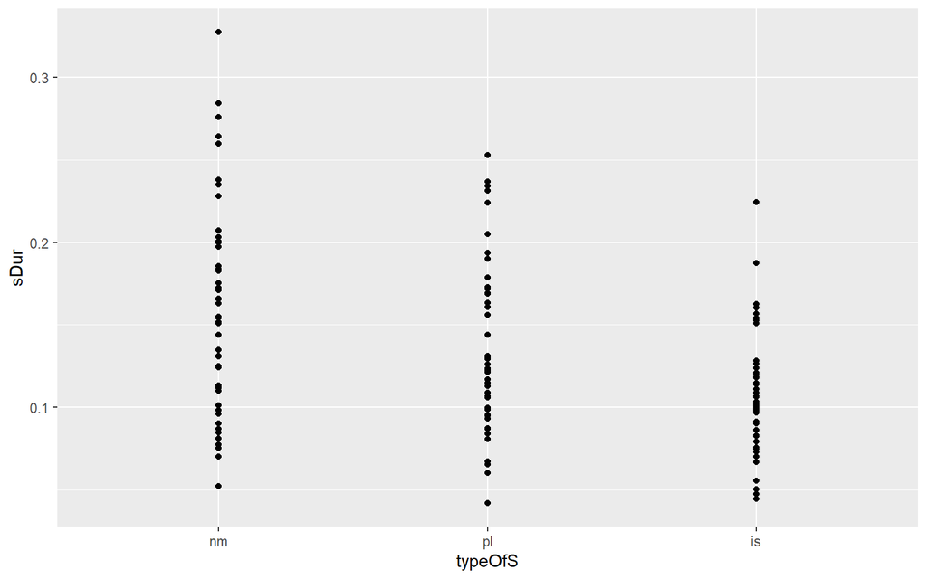

```r
ggplot(data_s, aes(x=typeOfS, y=sDur)) +
  geom_point()
```

Unsurprisingly, the can also be modified:

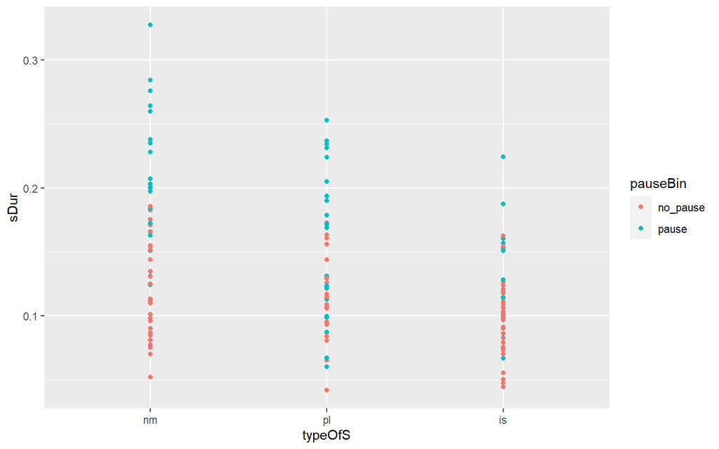

```r
ggplot(data_s, aes(x=typeOfS, y=sDur, color=pauseBin)) +
  geom_point()
```

## Exercises

Create two point plots using the `data_v` data set.

**Solution**

Two possible plots are:

```r
data("data_v")

ggplot(data_v, aes(x=structure, y=duration)) +
  geom_point()

ggplot(data_v, aes(x=vowel, y=duration, color=structure)) +
  geom_point()
```

# 06 Jitter Plot

Jitter plots are the more popular sibling of point plots. In comparison, they perform much better in terms of readability:

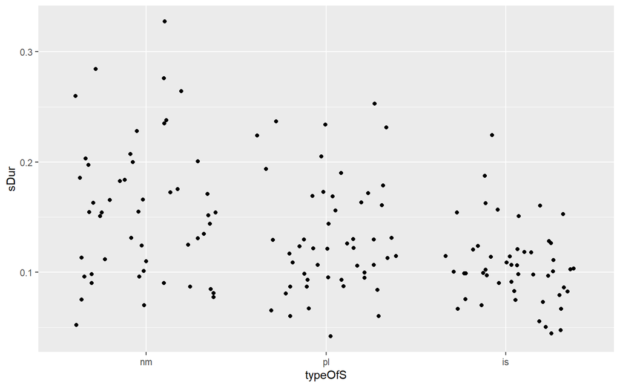

```r
ggplot(data_s, aes(x=typeOfS, y=sDur)) +
  geom_jitter()
```

Adding a second grouping variable as colour code works without a problem:

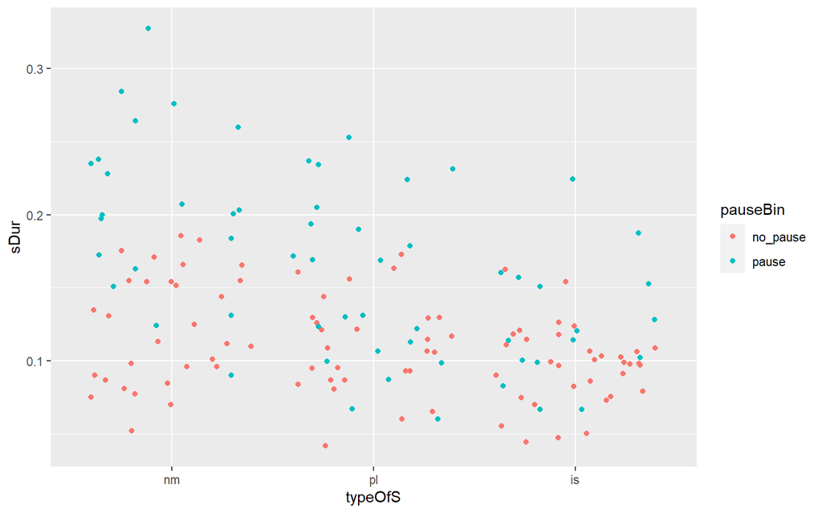

```r
ggplot(data_s, aes(x=typeOfS, y=sDur, color=pauseBin)) +
  geom_jitter()
```

## Exercises

Create two jitter plots using the `data_v` data set.

**Solution**

Two possible plots are:

```r
data("data_v")

ggplot(data_v, aes(x=structure, y=duration)) +
  geom_jitter()

ggplot(data_v, aes(x=vowel, y=duration, color=structure)) +
  geom_jitter()
```

# 07 Histogram

Histograms are the old-fashioned go-to plot to check a variable’s distribution.

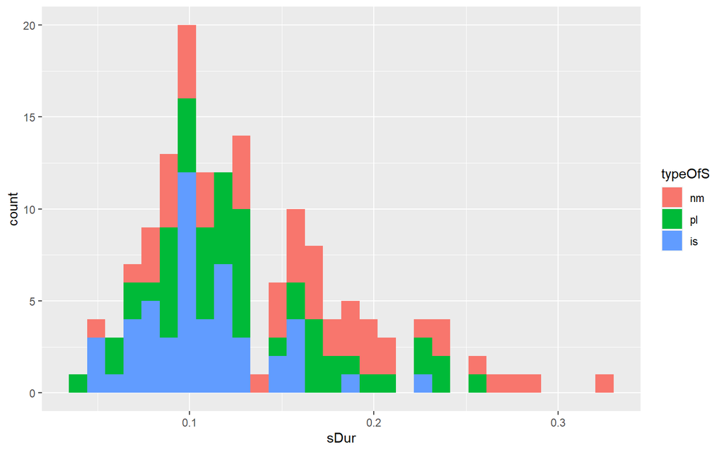

```r
ggplot(data_s, aes(x=sDur, fill=typeOfS)) +
  geom_histogram()
```

Histograms are quite unique in that they make use of *bins*. Let’s have a look at what the `bins` argument changes:

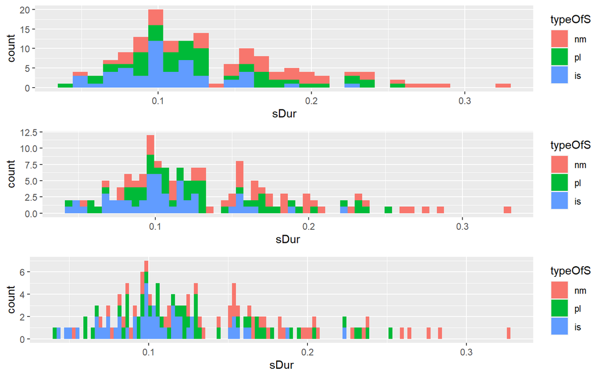

```r
# first, we create the same plot 3 times - with different 'bins' values

plot1 <- ggplot(data_s, aes(x=sDur, fill=typeOfS)) +
  geom_histogram(bins=30) # this is the default number of bins

plot2 <- ggplot(data_s, aes(x=sDur, fill=typeOfS)) +
  geom_histogram(bins=60)

plot3 <- ggplot(data_s, aes(x=sDur, fill=typeOfS)) +
  geom_histogram(bins=120)

# then, we plot them below each other for comparison
library(gridExtra)

ggarrange(plot1, plot2, plot3,
          ncol = 1, nrow = 3)
```

## Exercises

Create two histograms using the `data_v` data set.

**Solution**

Two possible plots are:

```r
data("data_v")

ggplot(data_v, aes(x=duration, fill=structure)) +
  geom_histogram()

ggplot(data_v, aes(x=duration, fill=vowel)) +
  geom_histogram()
```

# 08 Density Plot

The density plot is the smoother sibling of the histogram. In terms of readability and aesthetics, it is clearly the winner.

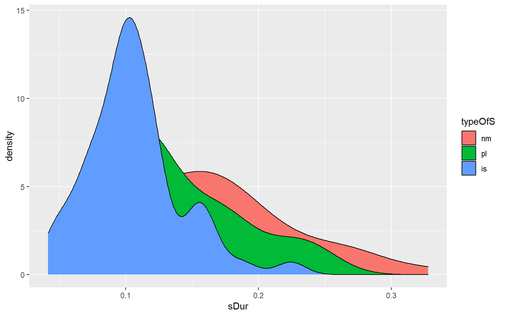

```r
ggplot(data_s, aes(x=sDur, fill=typeOfS)) +
  geom_density()
```

It is often useful to change the transparency of the density curves for better readability. This is done using the `alpha` argument:

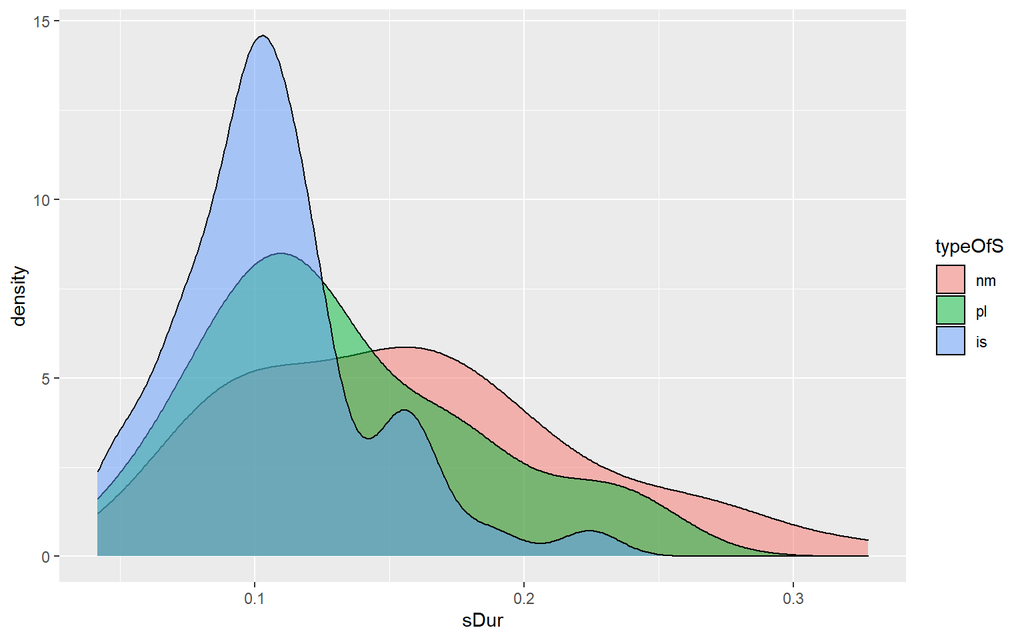

```r
ggplot(data_s, aes(x=sDur, fill=typeOfS)) +
  geom_density(alpha=0.5)
```

## Exercises

Create two density plots using the `data_v` data set.

**Solution**

Two possible plots are:

```r
data("data_v")

ggplot(data_v, aes(x=duration, fill=structure)) +
  geom_density()

ggplot(data_v, aes(x=duration, fill=vowel)) +
  geom_density(alpha=0.75)
```

# 09 Violin Plot

The violin plot is the long lost sibling of the density plot. Basically, the same information is given, but twice. This is especially visible when plotting tilted violins:

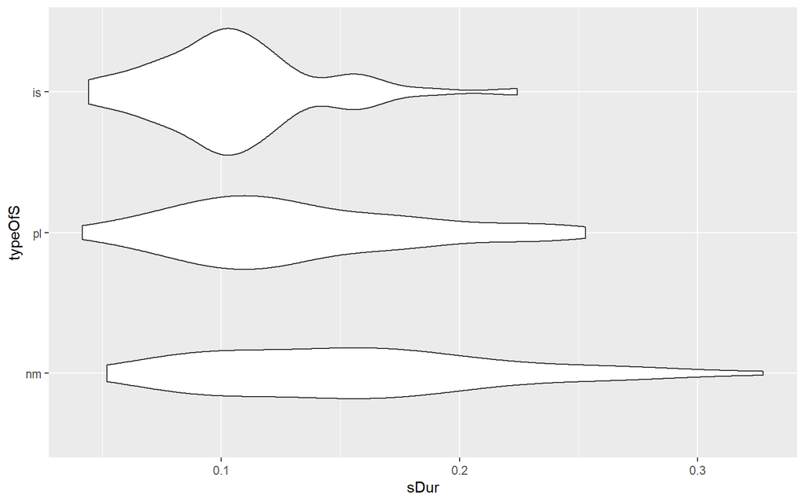

```r
ggplot(data_s, aes(x=sDur, y=typeOfS)) +
  geom_violin()
```

However, usually we like our violins standing up:

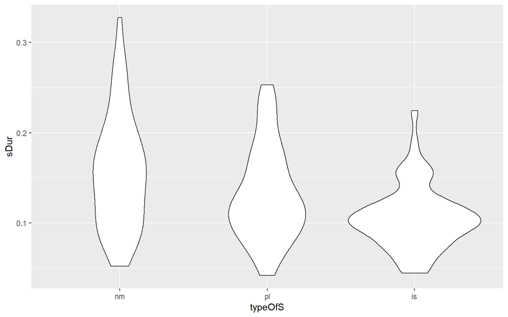

```r
ggplot(data_s, aes(x=typeOfS, y=sDur)) +
  geom_violin()
```

As for other plots, further modification is no problem:

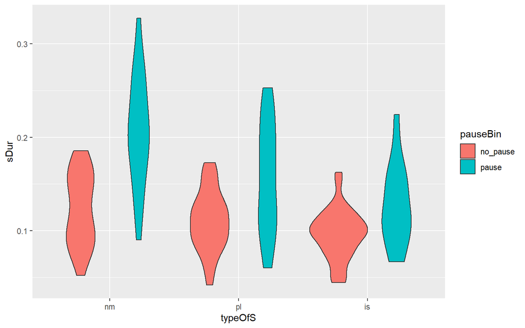

```r
ggplot(data_s, aes(x=typeOfS, y=sDur, fill=pauseBin)) +
  geom_violin()
```

Finally, violin plots are often combined with box plots to transport as much information as possible:

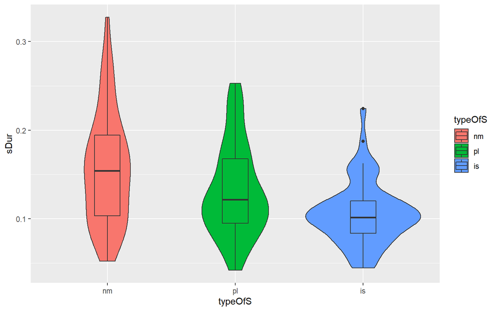

```r
ggplot(data_s, aes(x=typeOfS, y=sDur, fill=typeOfS)) +
  geom_violin()+
  geom_boxplot(width=0.2)
```

## Exercises

**Solution**

Two possible plots are:

```r
data("data_v")

ggplot(data_v, aes(x=structure, y=duration)) +
  geom_violin()

ggplot(data_v, aes(x=structure, y=duration, fill=vowel)) +
  geom_violin()
```

# 10 Even More Plots

There is almost an infinite amount of plot types - far too many for a complete overview. However, we wish to take a look at some more plot types that might come in handy.

## Stacked Bar Plots

Using a second variable for colour coding in a bar plot, i.e. not the variable used as `x` argument, creates a *stacked* bar plot:

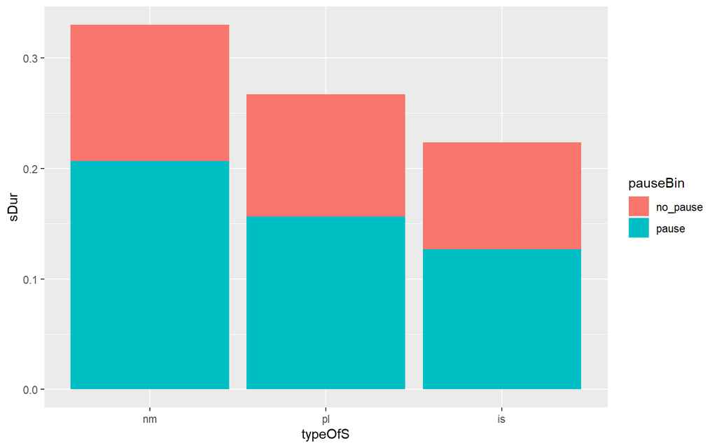

```r
ggplot(data_s, aes(x=typeOfS, y=sDur, fill=pauseBin)) +
  geom_bar(stat="summary", fun = "mean")
```

In most cases, such stacked bar plots are unwanted as their readability is quite bad. As an example, let’s try to find out the mean duration of `nm` /s/ with `no_pause` following. First, we have to eyeball the mean duration of `nm` /s/ with a `pause` following; that should be about $0.21$. Then, we must eyeball the upper end of the `nm` /s/ with `no_pause` bar; that should be around $0.33$. If we then subtract the value at start of the bar from the value the end of the bar, i.e. $0.33-0.21$, we obtain the mean duration we are looking for, i.e. $0.12$. As you can see, this is quite painful.

### Unstacking Stacked Bar Plots

Luckily, we can unstack stacked bar plots quite easily:

```r
ggplot(data_s, aes(x=typeOfS, y=sDur, fill=pauseBin)) +
  geom_bar(stat="summary", fun = "mean", position=position_dodge())
```

[output not shown]

The `position=position_dodge()` function unstacks all bars. Now, readability is no longer a problem.

### Exercises

Create a stacked bar plot using the `data_v` data set. Then, unstack it.

**Solution**

A way to create a stacked bar plot and then unstack it is:

```r
data("data_v")

ggplot(data_v, aes(x=structure, y=duration, fill=vowel)) +
  geom_bar(stat="summary", fun = "mean")

ggplot(data_v, aes(x=structure, y=duration, fill=vowel)) +
  geom_bar(stat="summary", fun = "mean", position=position_dodge())
```

## Bar Plots with Error Bars

Sometimes bar plots come with whiskers. These whiskers are *error bars* and they usually indicate +/- one standard deviation from the mean. Rarely, they instead indicate +/- one standard error.

Sadly, there is no function in base R or any package (at least to our knowledge) that can do this task. However, you are lucky. We created a function in the `SfL` package:

```r
library(SfL)

error_bar_dataframe <- create_error_bar_df(data = data_s, numerical = "sDur", factors = c("typeOfS", "pauseBin"))
```

In this new dataframe, i.e. `error_bar_dataframe`, we find all means and standard devations we need:

| typeOfS | pauseBin | sDur | sd |
| --- | --- | --- | --- |
| nm | no_pause | 0.1231257 | 0.0382272 |
| nm | pause | 0.2068315 | 0.0592810 |
| pl | no_pause | 0.1107015 | 0.0322990 |
| pl | pause | 0.1563617 | 0.0581802 |
| is | no_pause | 0.0966565 | 0.0267486 |
| is | pause | 0.1267245 | 0.0432609 |

As you can see, the `create_error_bar_df` function has computed a mean and standard deviation value for every combination of the factors we specified, i.e. `typeOfS` and `pauseBin`.

Now, we can plot our bar plot with error bars:

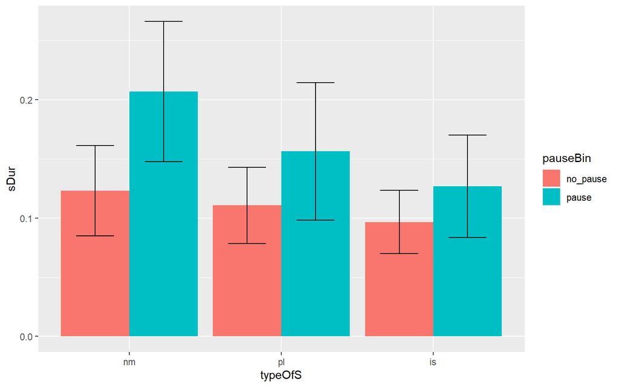

```r
ggplot(error_bar_dataframe, aes(x=typeOfS, y=sDur, fill=pauseBin)) +
  geom_bar(stat="identity", position=position_dodge()) +
  geom_errorbar(aes(ymin=sDur-sd, ymax=sDur+sd),
                width=.5,
                position=position_dodge(.9))
```

As you can see, we now have specified `error_bar_dataframe` in the `data` element. Further, the `stat` argument in the `geom_bar` function is no longer `summary` but `identity`. Before, the mean of our groups was computed by the plot function; now it is already given in the dataframe. Thus, a `summary` is no longer needed.

Now, to add the error bars, the `geom_errorbar` function is added as a second `geom` element. In ggplot2, you can add as many `geom` objects to your plot as you want. In the `geom_errorbar` function, we specify that the lowest points of the error bars should be `sDur-sd`, and the highest points should be `sDur+sd`. That is, the error bars show a range of 2 standard deviations around the mean. The `width` argument is used to change to horizontal lines at the end of the whiskers; the `position` argument is used to unstack the whiskers.

### Exercises

Create a bar plot with error bars using the `data_v` data set.

**Solution**

This is one possible way of doing it. Of course, if you chose other variables, the solution should look slightly different.

```r
library(SfL)

data("data_v")

error_bar_dataframe_2 <- create_error_bar_df(data = data_v, numerical = "duration", factors = c("structure", "vowel"))

ggplot(error_bar_dataframe_2, aes(x=vowel, y=duration, fill=structure)) +
  geom_bar(stat="identity", position=position_dodge()) +
  geom_errorbar(aes(ymin=duration-sd, ymax=duration+sd),
                width=.5,
                position=position_dodge(.9))
```

## Highlight Plots

Using the `gghighlight` package, one can create plots with highlighted areas. This can be combined with different types of plots - this example uses density plots.

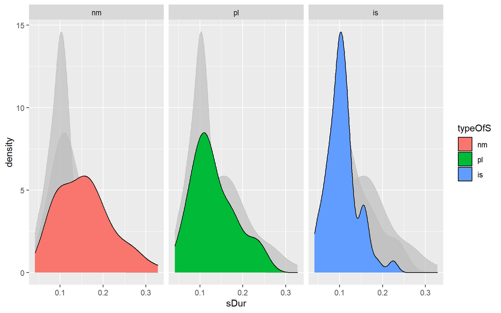

```r
library(gghighlight)

ggplot(data_s, aes(x=sDur, fill=typeOfS)) +
  geom_density() +
  gghighlight() +
  facet_wrap(~ typeOfS)
```

### Exercises

Create a histogram version of the above highlight density plot.

**Solution**

```r
library(gghighlight)

ggplot(data_s, aes(x=sDur, fill=typeOfS)) +
  geom_histogram() +
  gghighlight() +
  facet_wrap(~ typeOfS)
```

## Density Quantile Plots

The `ggridges` package allows us to highlight quantiles in density plots:

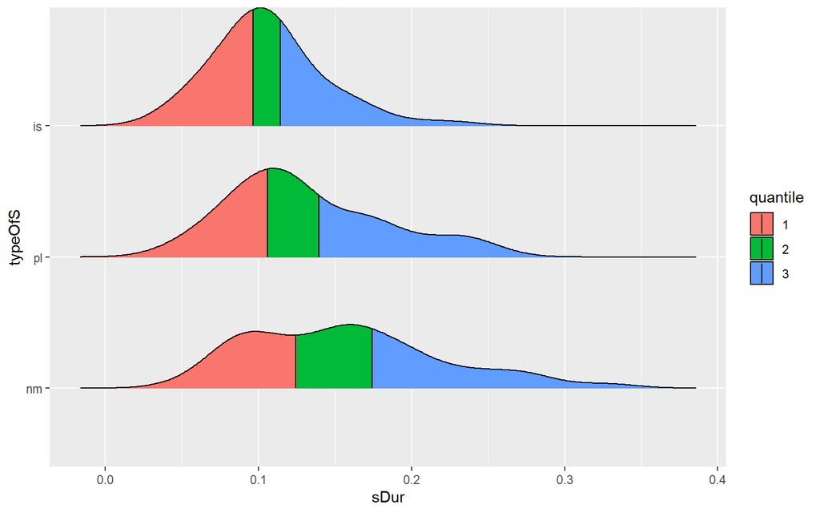

```r
library(ggridges)

ggplot(data_s, aes(x=sDur, y=typeOfS, fill=stat(quantile))) +
  stat_density_ridges(
    geom = "density_ridges_gradient", scale=0.9,
    quantiles = 3, quantile_lines = TRUE)
```

### Exercises

Re-create the above density quantile plot using different `x` and `y` variables.

**Solution**

One possible density quantile plot is:

```r
library(ggridges)

ggplot(data_s, aes(x=baseDur, y=pauseBin, fill=stat(quantile))) +
  stat_density_ridges(
    geom = "density_ridges_gradient", scale=0.9,
    quantiles = 3, quantile_lines = TRUE)
```

## Ellipse Plot

Visualising two numerical variables can sometimes be tricky. Adding ellipses using the `ggforce` package is an easy way to keep your plot readable:

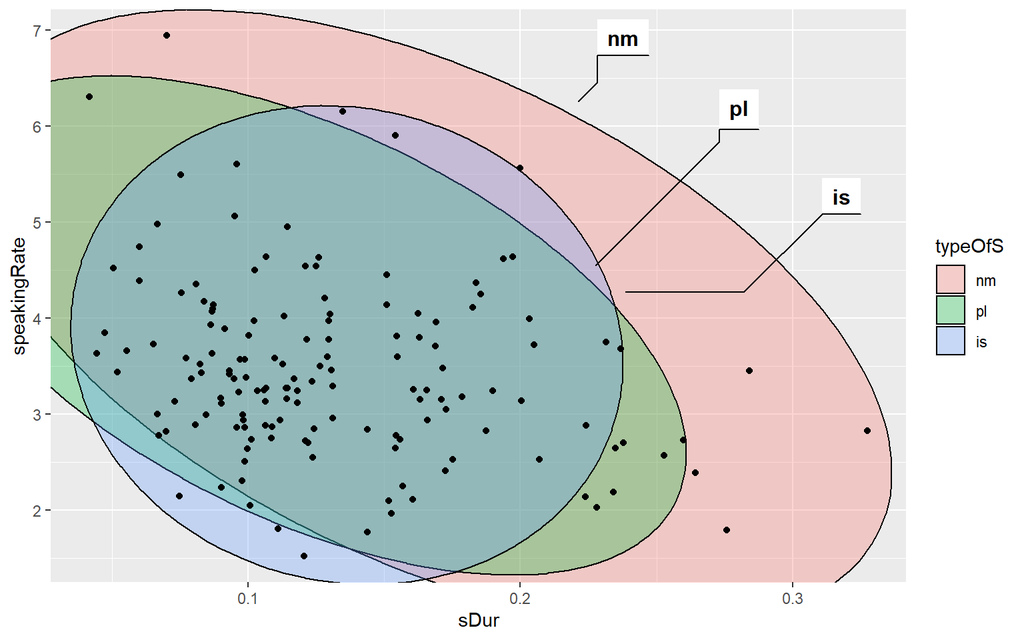

```r
library(ggforce)

ggplot(data_s, aes(x=sDur, y=speakingRate)) +
  geom_mark_ellipse(aes(fill=typeOfS, label=typeOfS))+
  geom_point()
```

### Exercises

Re-create the above ellipse plot using different `x` and `y` variables.

**Solution**

One possible ellipse plot is:

```r
library(ggforce)

ggplot(data_s, aes(x=baseDur, y=pauseDur)) +
  geom_mark_ellipse(aes(fill=typeOfS, label=typeOfS))+
  geom_point()
```

## Density Ridge Plot

Density ridge plots are introduced by the `ggridges` package. They are especially useful when normal density plots become too crowded. Compare:

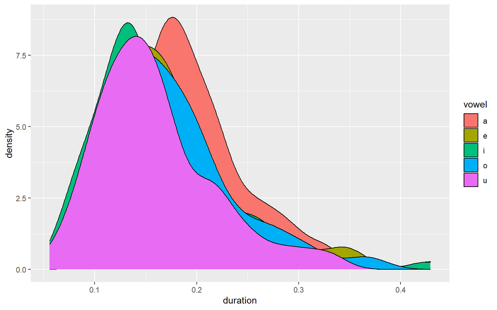

```r
data(data_v)

ggplot(data_v, aes(x=duration, fill=vowel)) +
  geom_density()
```

and

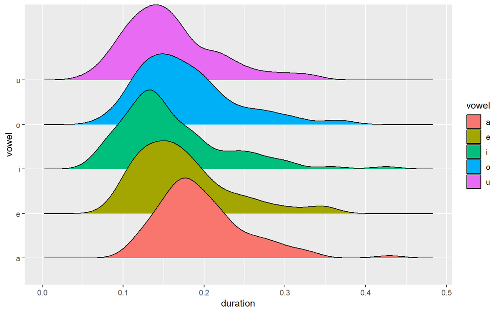

```r
library(ggforce)

ggplot(data_v, aes(x=duration, y=vowel, fill=vowel)) +
  geom_density_ridges()
```

### Exercises

Re-create the density plot found in section 08 as density ridge plot.

**Solution**

```r
# the density plot as found in section 08
ggplot(data_s, aes(x=sDur, fill=typeOfS)) +
  geom_density()

# the density ridge plot
library(ggforce)

ggplot(data_s, aes(x=sDur, y=typeOfS, fill=typeOfS)) +
  geom_density_ridges()
```

# 11 Plot Modification

`ggplot2` offers endless ways to modify your plots. We will take a look at some standard modifications in this section.

All examples will use the same standard bar plot:

```r
ggplot(data_s, aes(x=typeOfS, y=sDur, fill=pauseBin)) +
  geom_bar(stat="summary", fun = "mean", position=position_dodge())
```

## Colour

You can change the colours `ggplot2` uses to colour your plot manually:

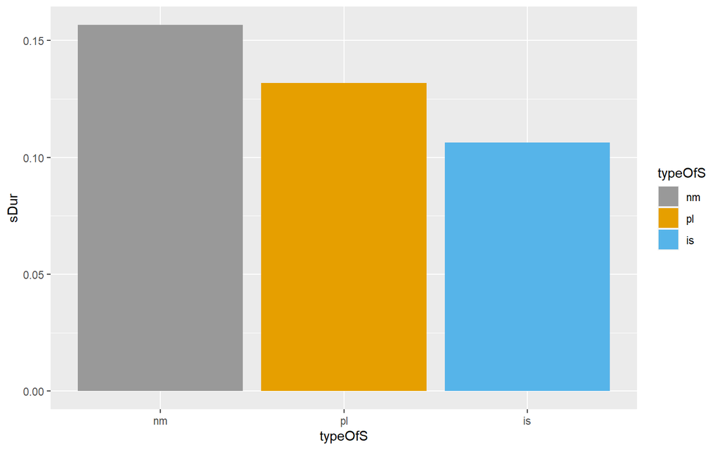

```r
ggplot(data_s, aes(x=typeOfS, y=sDur, fill=typeOfS)) +
  geom_bar(stat="summary", fun = "mean") +
  scale_fill_manual(values=c("#999999", "#E69F00", "#56B4E9")) # use your own colours
```

You can also use pre-defined colour palettes:

[figure not shown]

```r
ggplot(data_s, aes(x=typeOfS, y=sDur, fill=typeOfS)) +
  geom_bar(stat="summary", fun = "mean") +
  scale_fill_brewer(palette="Dark3")
```

## Title and Axis Labels

You can easily add a title and change axis labels of plots:

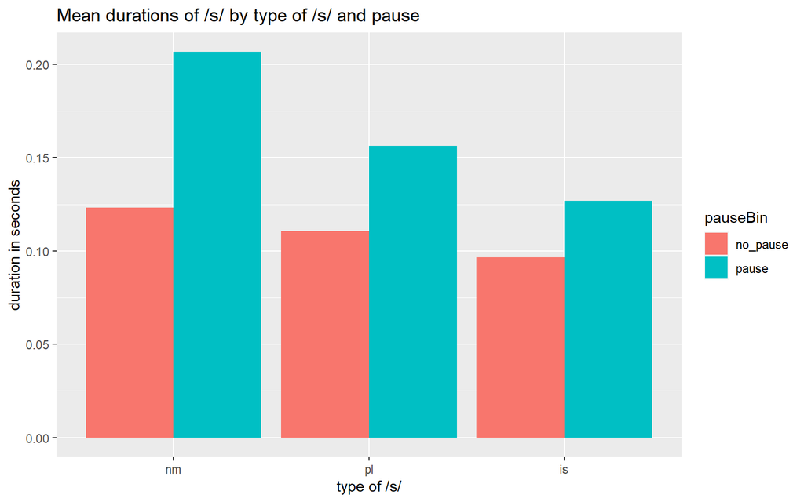

```r
ggplot(data_s, aes(x=typeOfS, y=sDur, fill=pauseBin)) +
  geom_bar(stat="summary", fun = "mean", position=position_dodge()) +
  ggtitle("Mean durations of /s/ by type of /s/ and pause") +
  xlab("type of /s/") +
  ylab("duration in seconds")
```

Font size, colour, weight, and angle can be changed as well:

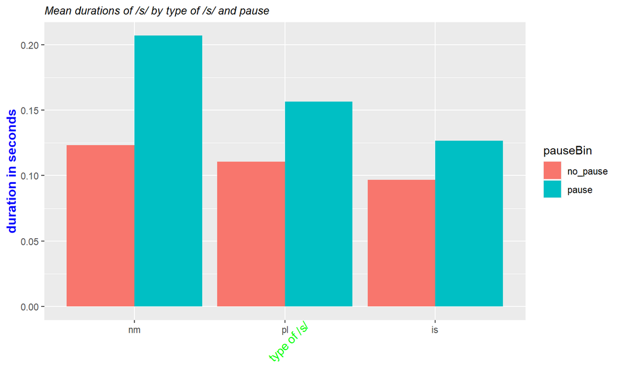

```r
ggplot(data_s, aes(x=typeOfS, y=sDur, fill=pauseBin)) +
  geom_bar(stat="summary", fun = "mean", position=position_dodge()) +
  ggtitle("Mean durations of /s/ by type of /s/ and pause") +
  xlab("type of /s/") +
  ylab("duration in seconds") +
  theme(plot.title = element_text(size=10, face="italic"),
        axis.title.x = element_text(color="green", angle=45),
        axis.title.y = element_text(color="blue", size=12, face="bold"))
```

### Exercises

Take a previously discussed plot. Add a title, axis labels, and change their appearance.

## Legend Title and Position

The legend title of your plot can be changed as well:

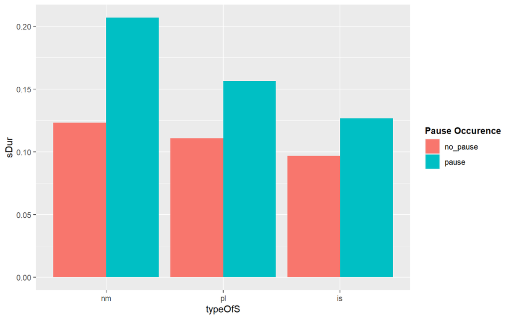

```r
ggplot(data_s, aes(x=typeOfS, y=sDur, fill=pauseBin)) +
  geom_bar(stat="summary", fun = "mean", position=position_dodge()) +
  labs(fill="Pause Occurence") +
  theme(legend.title = element_text(size=10, face="bold"))
```

Legends on the right side of the plot are boring? You are right, let’s change positions:

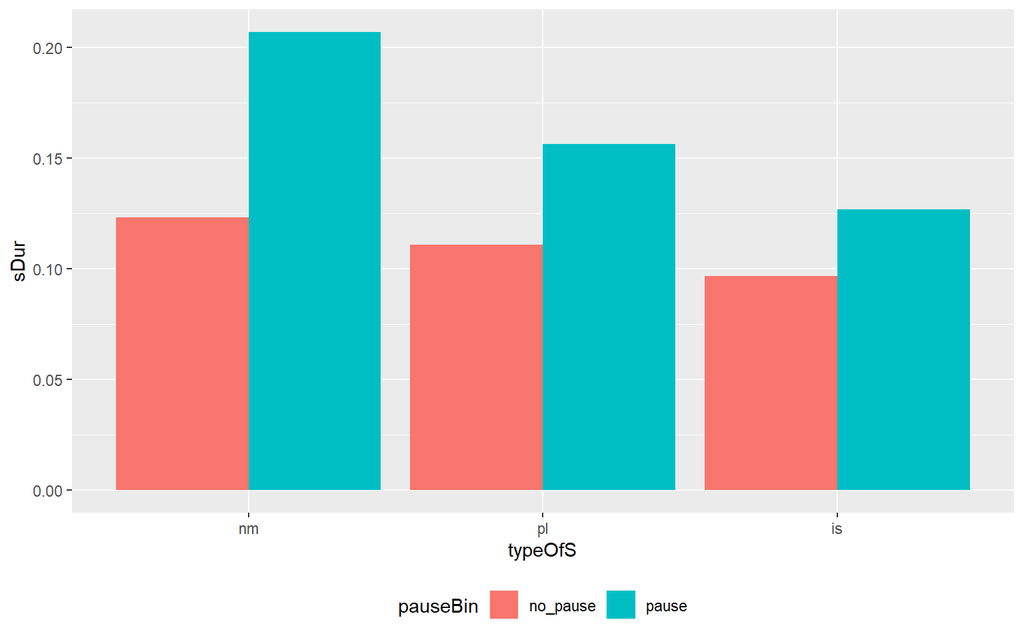

```r
ggplot(data_s, aes(x=typeOfS, y=sDur, fill=pauseBin)) +
  geom_bar(stat="summary", fun = "mean", position=position_dodge()) +
  theme(legend.position = "bottom")
```

The `legend.position` argument can take `"top"`, `"bottom"`, `"left"`, and `"right"` as input.

### Exercises

Take a previously discussed plot. Edit its legend titles and legend position.

## Facets

Using facets you can split one plot into many:

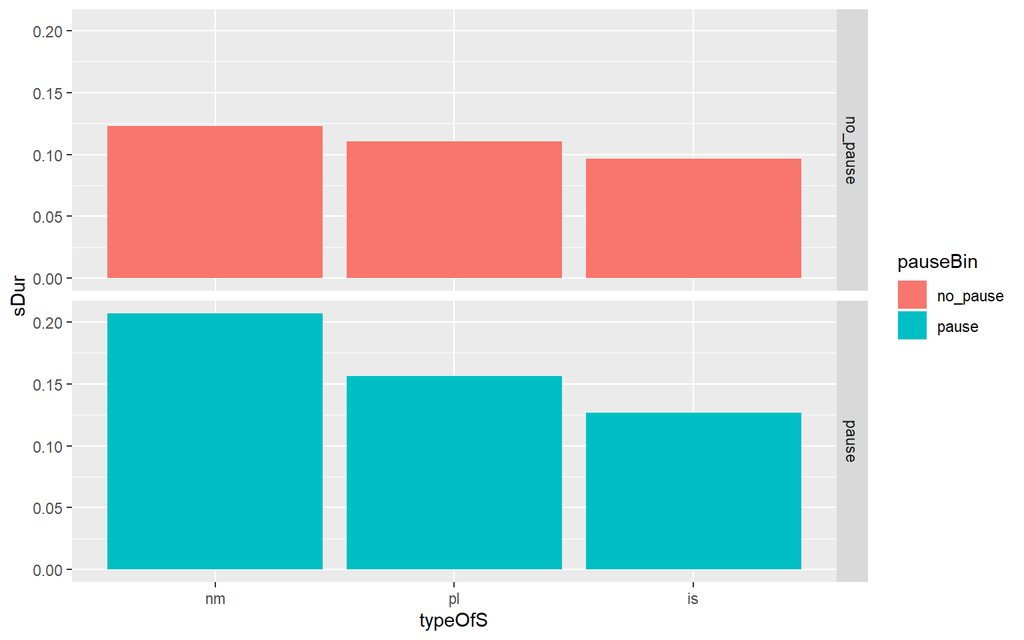

```r
ggplot(data_s, aes(x=typeOfS, y=sDur, fill=pauseBin)) +
  geom_bar(stat="summary", fun = "mean", position=position_dodge()) +
  facet_grid(pauseBin ~ .)
```

Taking a closer look at the `facet_grid()` function, we find that order matters:

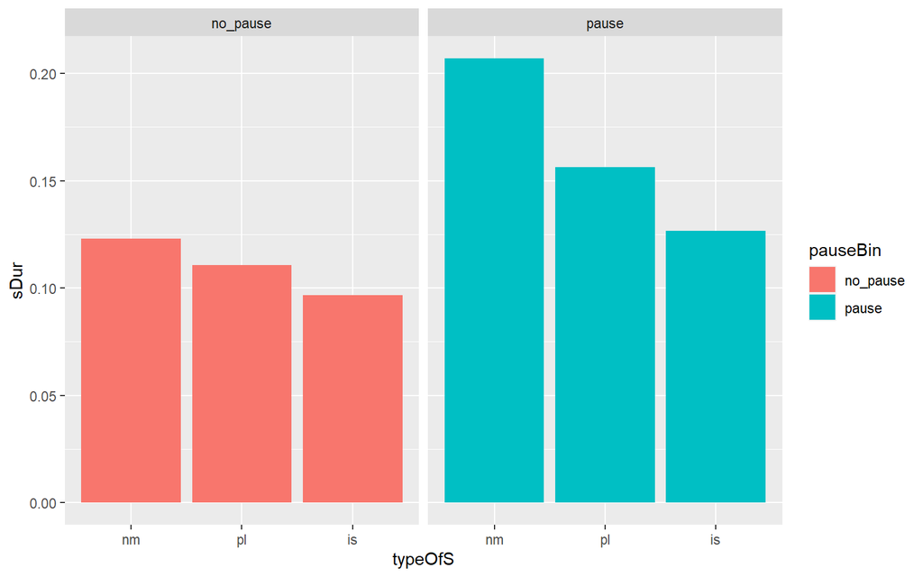

```r
ggplot(data_s, aes(x=typeOfS, y=sDur, fill=pauseBin)) +
  geom_bar(stat="summary", fun = "mean", position=position_dodge()) +
  facet_grid(. ~ pauseBin)
```

### Exercises

Take a previously discussed plot and add the `facet_grid()` function.

## Themes

The default theme is `theme_gray()`:

```r
ggplot(data_s, aes(x=typeOfS, y=sDur, fill=pauseBin)) +
  geom_bar(stat="summary", fun = "mean", position=position_dodge()) +
  theme_gray()
```

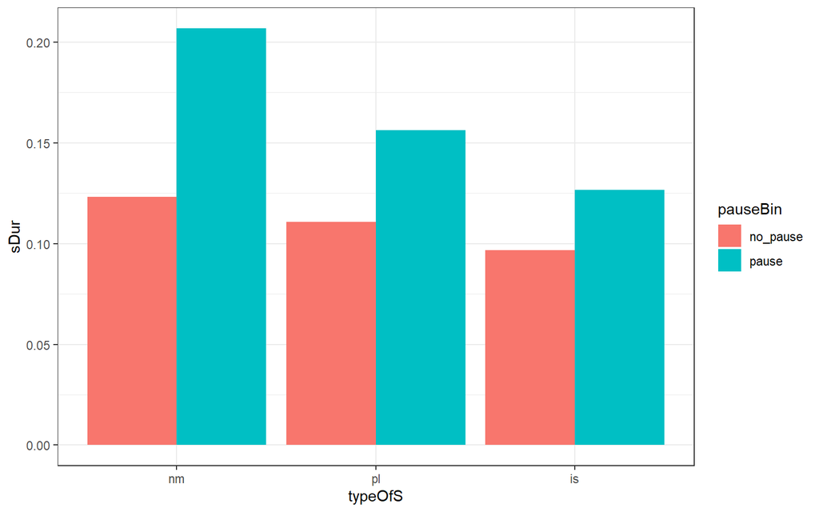

```r
ggplot(data_s, aes(x=typeOfS, y=sDur, fill=pauseBin)) +
  geom_bar(stat="summary", fun = "mean", position=position_dodge()) +
  theme_bw()
```

The following plots give an overview of most themes currently available:

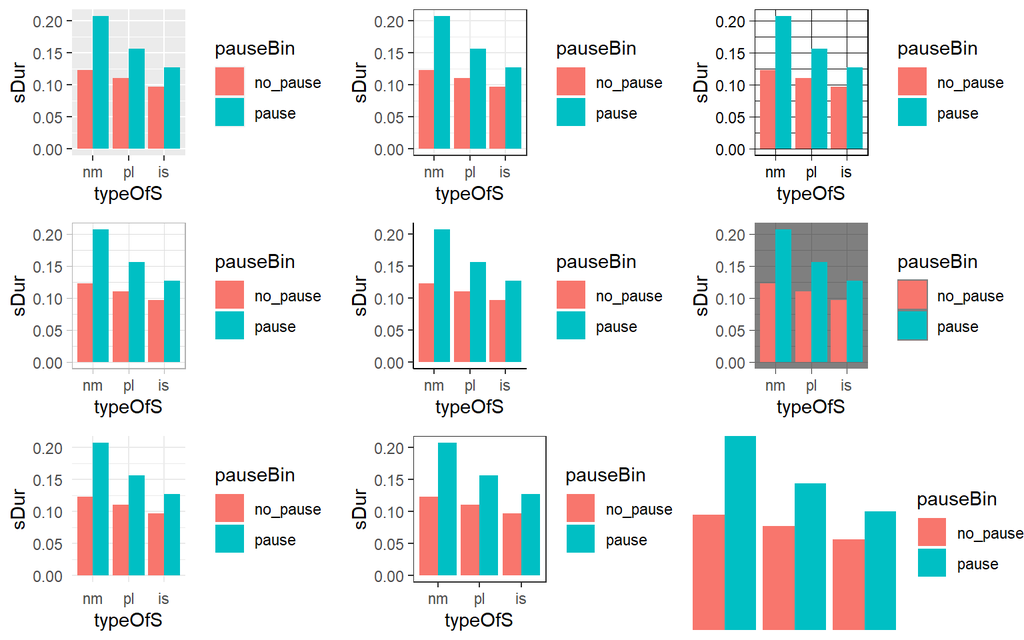

The theme names are (from left to right, from top to bottom):  
`bp_gray`, `bp_bw`, `bp_linedraw` | `bp_light`, `bp_classic`, `bp_dark` | `bp_minimal`, `bp_test`, `bp_void`

### Exercises

Take a previously discussed plot and change its theme a few times.

## More, More, More!

ggplot2 offers plenty more possibilities - far too many to cover in our introduction. Take a look at the following resources for more information:

- [ggplot2 - Essentials](http://www.sthda.com/english/wiki/ggplot2-essentials)
- [ggplot2 - tidyverse](https://ggplot2.tidyverse.org/)
- [Top 50 ggplot2 Visualizations](http://r-statistics.co/Top50-Ggplot2-Visualizations-MasterList-R-Code.html)